# Butadiene Conformational Preferences

#### Computational Chemistry Chris Harris 15 Nov 2003 A periodic study of ligands attached to the butadiene were carried out through semiempirical calculations. Of interest, were conformational preferences and rotational barriers. Only saturated ligands attached to the number two carbon were considered. Butadiene was calculated to have a 0.7730 kcal/mol difference between cis and trans configurations, while the rotational barrier approached 1.9624 kcal/mol. Semiempirical mathematical modeling of chemical compounds involves approximating the electron core with a core potential and looking at the valence electrons to predict chemical properties. The valence electron basis sets are fitted to trial experimental data, which may or may not reflect properties similar to the molecule of interest. Although absolute energy values are in significant error, semiempirical methods do take into account pi interactions, to elucidate energy differences between chemical structures. In comparison, molecular modeling techniques tend to calculate geometry better than semiempirical counterparts, but the force fields usually ignore pi effects unless specifically told to consider such phenomena. As such, molecular modeling techniques generally lead to less accurate energy calculations relative to semiempirical methods. With pi electron consideration, the semiempirical approach may reveal the conformational landscape within butadiene. An example of a conjugated pi system, butadiene has two stable, planar conformations, cis and trans. The energy difference between the two structures, the rotational barrier separating the two states, and ligand influences on these properties, make this an intriguing inquiry. *1,3-butadiene* Use Spartan’s energy profile feature to rotate the central bond of butadiene through a dihedral angle of 0 to 360 degrees. Structurally, the cis conformation has a 0 degree dihedral angle, while the trans configuration possesses a 180 degree dihedral. Since no transition metals are present, compute semiempirical energies with AM1 parameters, rather than PM3 coefficients. Replace a hydrogen on the backbone of the central butadiene bond with another saturated substituent within the second row of the periodic table: -CH<sub>3</sub>, -NH<sub>2</sub>, -OH, -F, to explore energy behavior. *Exchange hydrogen on # 2 carbon* **Figure 1**: Dihedral Energy Curve, kcal/mol vs deg *Trans* *Cis* (a) Butadiene (b) CH<sub>3</sub> Group (c) F Group (d) OH Group (e) NH<sub>2</sub> Group **Table 1**: Energy Topography *kcal/mol:* *E cis* *E trans* *∆E conform* *∆E barrier* Butadiene 30.6871 29.9141 0.7730 1.9624 -CH<sub>3</sub> 23.2403 23.3324 -0.0921 1.4102 -NH<sub>2</sub> 32.1558 29.7762 2.3796 2.5761 -OH -14.2547 -14.1051 -0.1497 2.2537 -F -14.5744 -14.6574 0.0830 2.2010 *E cis, E trans = total energy* *∆E conform = E cis - E trans* *∆E barrier = rotation barrier* Starting with the total energy trends, -CH<sub>3</sub> decreases the overall molecular energy, by adding another carbon to delocalize and stablize the pi electron orbitals. In contrast, -NH<sub>2</sub>, where the N atom contributes 5 electrons to the pi shell, starts to fill antibonding orbitals. The energy difference between the ammonia pi orbitals and the carbon pi orbitals leads to less effective overlap, causing localization and destablization within the molecule. However; when you reach group 6 and 7 for -OH and -F, respectively, the electronegative forces start to dominate the molecular interactions, behaving as Lewis acids, to draw electrons away from the carbon pi system, delocalizing and stablizing the molecular orbitals for the overall structure. Only -OH and -CH<sub>3</sub> favor the cis conformation over the trans configuration. Having the most dramatic influence on energetics, the H atom on the backbone of the butadiene central bond is chosen for substituent replacement, with its close proximity to the neighboring hydrogen, relative to the terminating hydrogens, on both ends of the molecule. Thus, my interpretation of the cis versus trans preferences should be determined by a balance between short range forces between the two central substituents and the long range forces present among the terminating hydrogens. With this model in mind, let’s consider the results. For the cis configuration, fluorine lowers ∆E conform relative to butadiene, perhaps due to weak hydrogen bonding between the fluorine and the hydrogen attached to the interior carbon. This hydrogen bonding effect is enhanced for an -OH ligand, leading to a negative ∆E conform. With the methyl substituent, more interactions come into play, leading to a negative ∆E conform, while experiencing a diminished rotational barrier, relative to butadiene. Perhaps a torsional vibration mode, methane and butadiene exhibit a slight upthrust in energy at the 0 degree position, straddling two local minimums. In relation to -OH, the -F group has a flat bottom at the cis orientation, suggesting a muted influence of a vibrational state observed in methane and butadiene. For the -NH<sub>2</sub> ligand, the energies come into question, because one would expect a symmetric curve about the 0 level dihedral angle. Discontinuity between the cis position and neighboring energy points reinforces the concern regarding mathematical integrity. The strong Lewis acid behavior observed in -OH and -F may account for the substantially lower overall molecular energy relative to butadiene. Hydrogen bonding along the backbone of the butadiene seems to stabilize the cis configuration for -OH and -F, while the methyl ligand lowers the rotational energy barrier. Although the ammonium calculations seem unrealistic on a semiempirical level, they offer some compelling results for molecular orbital calculations.

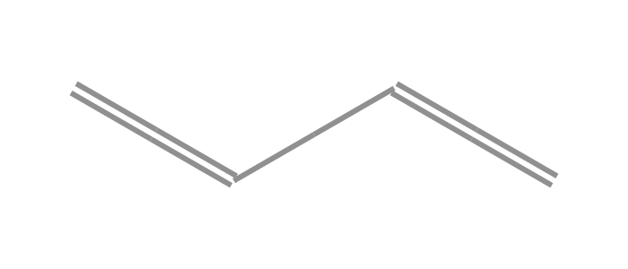

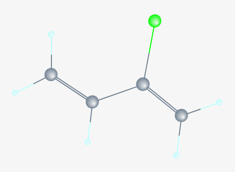

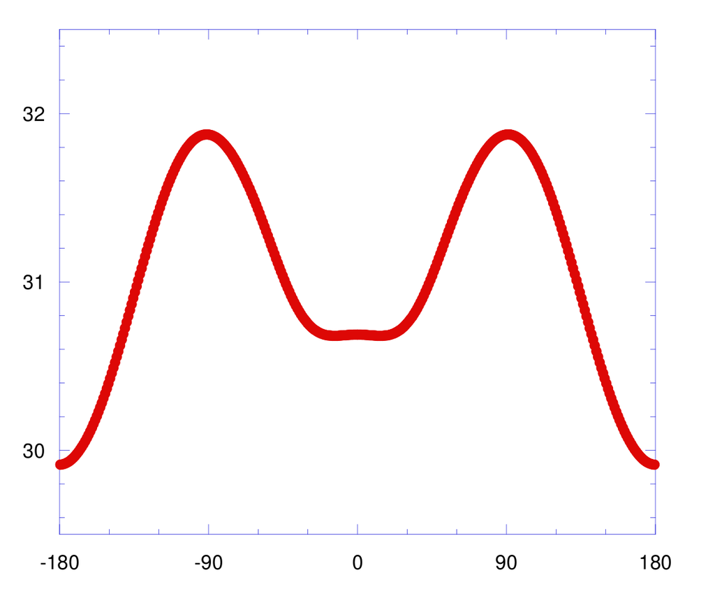

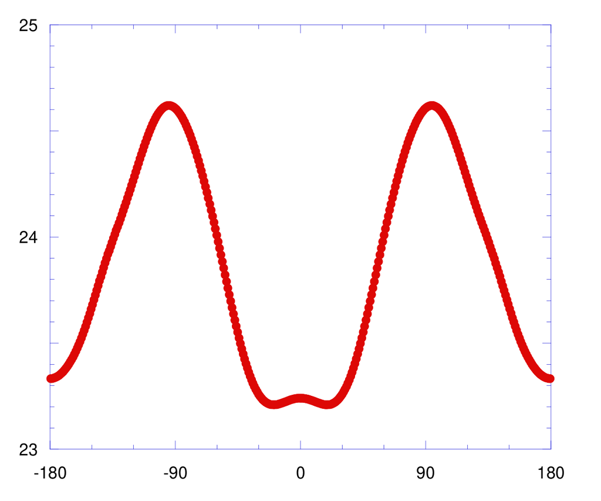

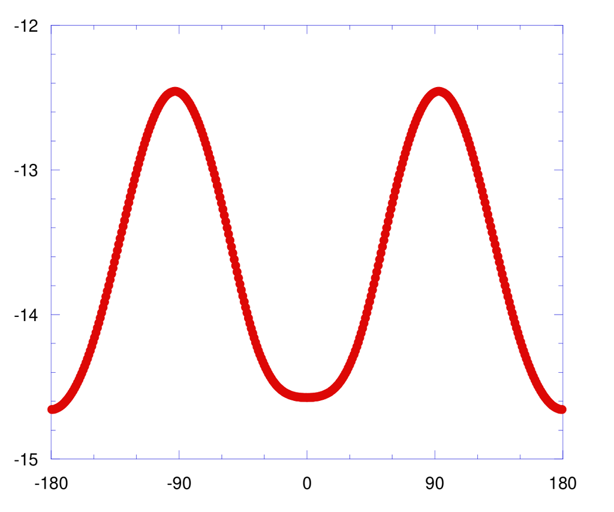

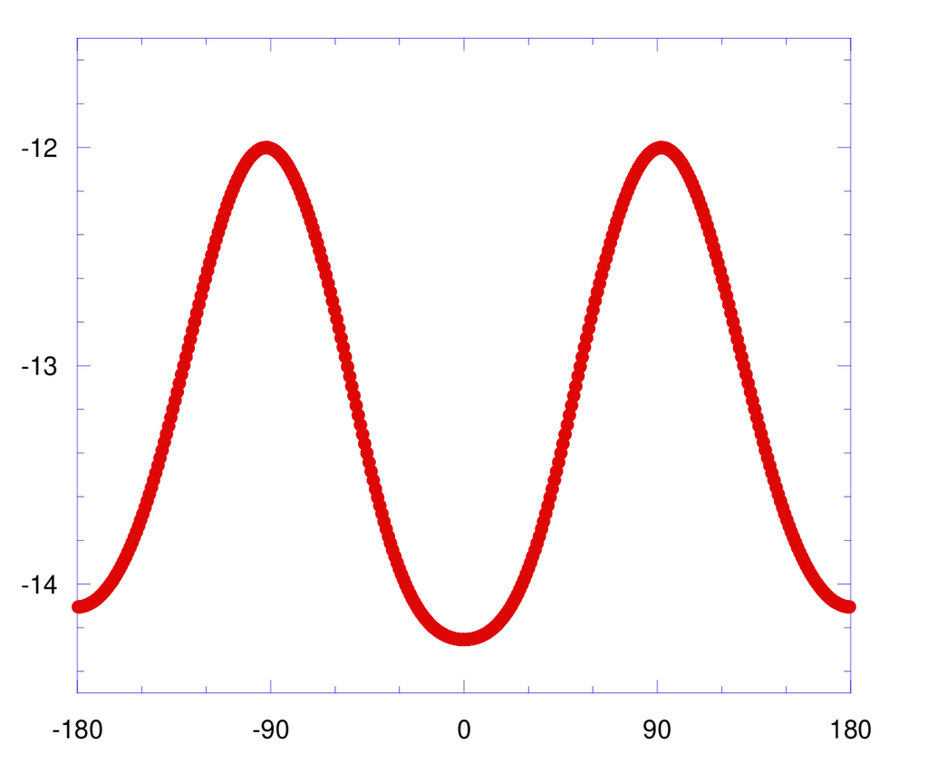

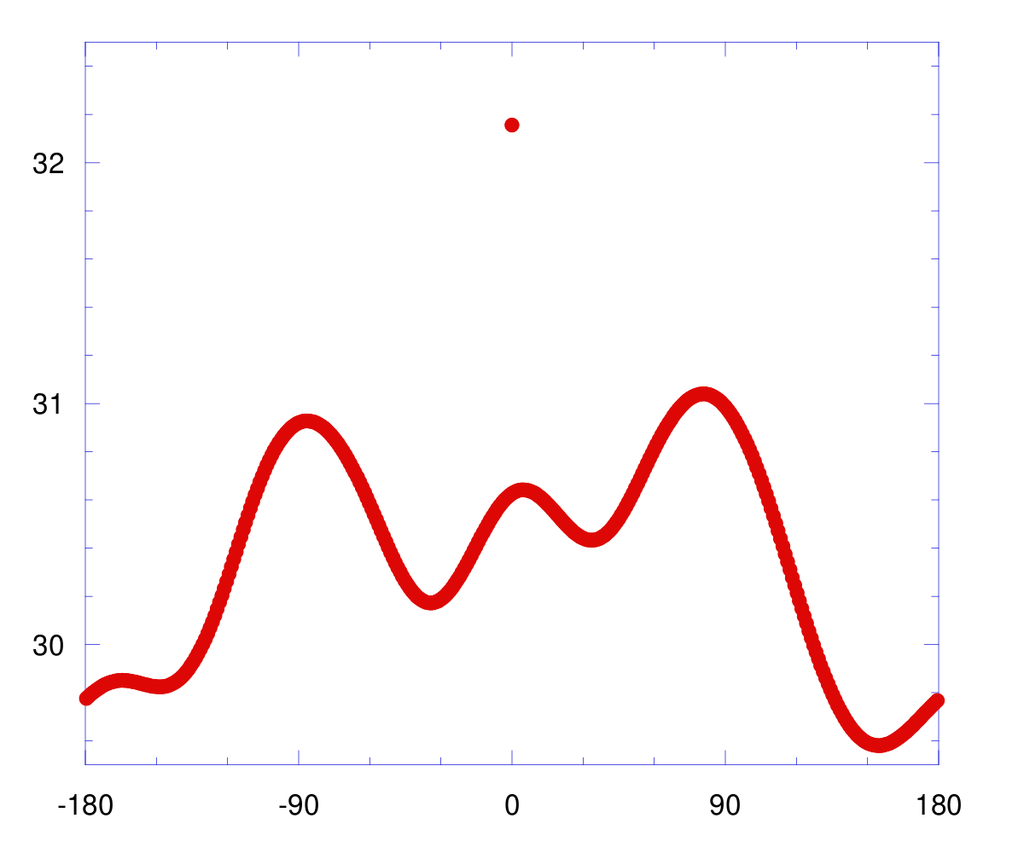